# Module4-note

Sung

11/12/2020

# Module 4 overview

What to do after a list of genes or snips? How to summarize them and communicate them.

1. Gene Set Enrichment Analysis
- a way to combine all of the statistically significant results what those genes or snps do -> bigger picture.
2. eQTL study
- combine multiple different genomic measurement to identify snps variation associated with gene expression variation.
3. and so on.

## Gene set Enrichment

Once you fit a statistical model and you have identified those genes or those features that are statistically significantly associated with the phenotype after correcting for multiple testing. You might want to identify if there is some biological pattern to those genes.

If all of the genes in the defined gene set cluster near the most statistically significant values, you will values going up. The statistic here is a max deviation from zero related to Kolmogorov-Smirnov stat.

One way to test significance is to permute the sample labels. Then p-value to see if permuted value is further from observed value.

- Sometimes still very hard to interpret GSE, especially if the categories are broad/vague.
- It is easy to tell stories if you aren't careful.
- Incurs a second mutliple testing problem.
- Can be simplified.

## More Enrichment

Enrichment analysis can be useful for summarizing results that are statistically significant for a number of different things. Here, we discuss two particular sets of results and if they are enriched for one another.

SNPs from eQTL and GWAS, we want to know if they are enriched with respect to one another. One thing is count the number of eQTLs that correspond to SNPs that are in particular set of GWAS hits.

- Getting the null right is very hard

## Gene Set Analysis in R

After you are done with differential analysis, you want to combine the results into some interpretable story. One way to do that is use gene set enrichment analysis to identify gene sets that are enriched among the differentially expressed genes.

```r
tropical = c("darkorange", "dodgerblue", "hotpink", "limegreen", "yellow")
palette(tropical)
par(pch=19)
```

```r
suppressPackageStartupMessages({
  library(devtools)
  library(Biobase)
  library(goseq)
  library(DESeq2)
  library(broom)
})
```

Which genome and gene id?

```r
head(supportedGenomes())
```

```
##         db species      date                               name
## 2     hg19   Human Feb. 2009 Genome Reference Consortium GRCh37
## 3     hg18   Human Mar. 2006                    NCBI Build 36.1
## 4     hg17   Human  May 2004                      NCBI Build 35
## 5     hg16   Human Jul. 2003                      NCBI Build 34
## 22 felCat3     Cat Mar. 2006          Broad Institute Release 3
## 27 panTro2   Chimp Mar. 2006                     CGSC Build 2.1
##                                                                                                                     AvailableGeneIDs
## 2                                                       ccdsGene,ensGene,exoniphy,geneSymbol,knownGene,nscanGene,refGene,xenoRefGene
## 3    acembly,acescan,ccdsGene,ensGene,exoniphy,geneSymbol,geneid,genscan,knownGene,knownGeneOld3,refGene,sgpGene,sibGene,xenoRefGene
## 4  acembly,acescan,ccdsGene,ensGene,exoniphy,geneSymbol,geneid,genscan,knownGene,refGene,sgpGene,vegaGene,vegaPseudoGene,xenoRefGene
## 5                                                       acembly,ensGene,exoniphy,geneSymbol,geneid,genscan,knownGene,refGene,sgpGene
## 22                                                           ensGene,geneSymbol,geneid,genscan,nscanGene,refGene,sgpGene,xenoRefGene
## 27                                                                          ensGene,geneSymbol,genscan,nscanGene,refGene,xenoRefGene
```

```r
head(supportedGeneIDs())
```

```
##     tablename         track           subtrack               GeneID
## 1   knownGene    UCSC Genes               <NA>       Entrez Gene ID
## 10   vegaGene    Vega Genes Vega Protein Genes HAVANA Pseudogene ID
## 12    ensGene Ensembl Genes               <NA>      Ensembl gene ID
## 27 geneSymbol       refGene            refFlat          Gene Symbol
##                                                                                                                                                                                                                                                                                                   Availab…
## 1                                                                                                                                                                                                                                                                          hg16,hg17,hg18,hg19,mm7,mm8,mm…
## 10                                                                                                                                                                                                                                                                                                    dan…
## 12 anoCar1,anoGam1,apiMel2,bosTau3,bosTau4,canFam1,canFam2,cavPor3,ce6,ci2,danRer3,danRer4,danRer5,danRer6,equCab2,felCat3,fr1,fr2,galGal2,galGal3,gasAcu1,hg16,hg17,hg18,hg19,mm7,mm8,mm9,monDom4,monDom5,ornAna1,oryLat2,panTro1,panTro2,ponAbe2,rheMac2,rn3,rn4,sacCer1,sacCer2,taeGut1,tetNig1,tetNig…
## 27                                 bosTau2,bosTau3,bosTau4,canFam1,canFam2,ce2,ce4,ce6,ci1,ci2,danRer3,danRer4,danRer5,danRer6,dm1,dm2,dm3,equCab1,equCab2,felCat3,galGal2,galGal3,hg16,hg17,hg18,hg19,mm7,mm8,mm9,monDom4,monDom5,ornAna1,oryLat2,panTro2,ponAbe2,rheMac2,rn3,rn4,strPur1,strPur2,taeGut…
```

load dataset from goseq

```r
temp_data = read.table(system.file("extdata","Li_sum.txt",
                                   package="goseq"),sep="\t",
                       header=TRUE,
                       stringsAsFactors=FALSE)

temp_data[1,] # let's remove this
```

```
##             genes lane1 lane2 lane3 lane4 lane5 lane6 lane8
## 1 ENSG00000215688     0     0     0     0     0     0     0
```

```r
expr = temp_data[,-1]
rownames(expr) = temp_data[,1]
expr = expr[rowMeans(expr) > 5,] # lowly expressed gene removal
grp = factor(rep(c("Control","Treated"),times=c(4,3)))
pdata = data.frame(grp)
```

Pass this data to DESeq

```r
de = DESeqDataSetFromMatrix(expr,pdata, ~grp)
de_fit = DESeq(de)
de_results = results(de_fit) # differential expression result
```

Find differentially expressed genes

```r
genes = as.integer(de_results$padj < 0.05)
not_na = !is.na(genes)
names(genes) = rownames(expr)
genes = genes[not_na]
```

calculate probability weight function

```r
pwf = nullp(genes, "hg19", "ensGene")
```

```
## Loading hg19 length data...
```

[figure not shown]

```r
head(pwf)
```

```
##                 DEgenes bias.data       pwf
## ENSG00000124208       0      1978 0.2276789
## ENSG00000224628       0      1510 0.2176689
## ENSG00000125835       0       954 0.2050611
## ENSG00000125834       0      6013 0.2874471
## ENSG00000197818       0      6295 0.2898591
## ENSG00000101181       0      2644 0.2431052
```

Calculate statistic for Enrichment

```r
Go.wall = goseq(pwf, "hg19", "ensGene")
```

```
## Fetching GO annotations...
```

```
## For 2046 genes, we could not find any categories. These genes will be excluded.
```

```
## To force their use, please run with use_genes_without_cat=TRUE (see documentation).
```

```
## This was the default behavior for version 1.15.1 and earlier.
```

```
## Calculating the p-values...
```

```r
head(Go.wall)
```

```
##         category over_represented_pvalue under_represented_pvalue numDEInCat
## 2162  GO:0005615            1.794315e-17                        1        485
## 10056 GO:0044421            9.619586e-17                        1        501
## 2144  GO:0005576            2.647772e-15                        1        555
## 13449 GO:0070062            8.992505e-15                        1        412
## 9606  GO:0043230            1.830479e-14                        1        413
## 17235 GO:1903561            1.830479e-14                        1        413
##       numInCat                      term ontology
## 2162      1411       extracellular space       CC
## 10056     1476 extracellular region part       CC
## 2144      1690      extracellular region       CC
## 13449     1203     extracellular exosome       CC
## 9606      1211   extracellular organelle       CC
## 17235     1211     extracellular vesicle       CC
```

Look at particular category

```r
GO.MF = goseq(pwf, "hg19", "ensGene", test.cats=c("GO:MF"))
```

```
## Fetching GO annotations...
```

```
## For 2046 genes, we could not find any categories. These genes will be excluded.
```

```
## To force their use, please run with use_genes_without_cat=TRUE (see documentation).
```

```
## This was the default behavior for version 1.15.1 and earlier.
```

```
## Calculating the p-values...
```

```r
head(GO.MF)
```

```
##        category over_represented_pvalue under_represented_pvalue numDEInCat
## 1003 GO:0005515            1.012745e-07                1.0000000       1814
## 907  GO:0005198            3.638902e-06                0.9999983        125
## 2974 GO:0050839            8.724112e-06                0.9999954        119
## 2695 GO:0045296            3.358503e-05                0.9999814         97
## 1974 GO:0023026            7.669333e-05                0.9999974          8
## 1930 GO:0019904            1.275925e-04                0.9999155        155
##      numInCat                                 term ontology
## 1003     6738                      protein binding       MF
## 907       353         structural molecule activity       MF
## 2974      324       cell adhesion molecule binding       MF
## 2695      262                     cadherin binding       MF
## 1974        9 MHC class II protein complex binding       MF
## 1930      465      protein domain specific binding       MF
```

## The Process for RNA-seq

Central dogma: DNA -> RNA -> protein

Imagine we have fragmented RNA, we want to capture that RNA molecule using it's poly(A) tail. This is one way to capture mature RNA. Then we can reverse transcribe it into complementary DNA, and you sequence it.

From that, we can identify RNA trasncripts by using the RNA sequencing reads.

### Step1: Align

Software: HiSat, Rail, Star, Tophat2

First you need to align reads to the genome, assuming that the genome is known.

### Step2: Count

Software: HTSeq, featureCounts, kallisto (does pseudo alignment), derfinder

Then you need to count the values that correspond to a particular gene. Count corresponding to the gene or transcript.

### Step2: Assemble and quantify

Software: StringTie, Cufflinks, Trinity, RSEM

Or we can assembly and quantify rather than counting.

### Step3: Normalization

Software for Normalize: EDAseq (GC content), cqn (GC content), DESeq2/edgeR (diff expression), Ballgown, derfinder

Software for Batch Effects: sva, RUVseq

### Step4: Statistical test

Software: DESeq2/edgeR (count data), Ballgown (transcript quantification), derfinder (single base resolution)

### Step5: Gene set enrichment

Software: goseq, SeqGSEA

## The Process for Chip-Seq

Chip-seq to measure the way proteins interact with DNA. Transcription regulation can be done by binding protein to the DNA. First step of this process is to cross-link proteins to DNA. Then you collected protein-DNA with antibody pulldown. Then we sequence them.

### Step1: Align

Software: Bowtie2, BWA

Straight alignment to the genome.

### Step2: Peak detection

Software: CisGenome, MACS, PICS

Peak detection to detect enriched particular sequence because they are pulled down by proteins. So we can find big piles of reads corresponding to those sequences.

### Step3: Count

Softare: CisGenome, MACS, diffbind

To obtain measurement for the amount of read covering a particular peak.

### Step4: Normalization

Software: diffbind, MAnorm

To make peak counts comparable to others.

### Step5: Statistical tests

Software: CisGenome, MACS, diffbind

To identify whether there's any differences between control and experiment.

### Step6: Sequence motifs & Annotations

Software: CisGenome, meme-suite, BioC Annotation Workflow

To understand what are the sequence motifs underlying that particular transcription factor.

## The Process for DNA Methylation

DNA methylation refers to a particular methyl group binding to CpG sites in the genome. One method to detect this is bisulfite conversion followed by sequencing. We split the DNA into two identical samples, so you randomly create two samples from the same set of DNA. Then we bisulfite convert one of the two samples changing un-methylated cytosine to urasil. After this, align two samples to the genome. By comparing level of converted samples, we can measure how much DNA methylation is at that location. Another way is through aluminum methylation arrays. It is similar to bisulfite conversion, but we hybridize them to microarray. Then we have unmethylated/methylated probes.

### Step1: Normalization

Software: minfi, charm

### Step2: Smoothing

Software: charm, bsseq

We want to find clump of points that are above a particular level.

### Step3: Region finding

Software: charm, bsseq

After smooting, we want to identify regions that are different.

### Step4: Annotation

Software: Charm, bsseq, BioC Annotation Workflow

To annotate the regions to different components of the genome or to particular category specific to DNA methylation.

## The Process for GWAS/WGS

Direct measurement of DNA variability: mutation, insertion or deletion. One way to do this is direct re-sequencing of DNA by DNA fragmentation. Then sequence. From this data, we look for variation from the reference or control, and quantify how much those variations associate with different outcome. 50/50 or 60/40 split may indicate heterzygote for a particular variant. Or we can do this with microarray for genome wide association study. Similar approach is used as we start from digestion of DNA. With fragmented samples, we compare them on probes, probes for homozygous reference allele, the homozygous variant and the heterozygote.

### Step1: Variant identification (SNP chip)

Software: crlmm

### Step1: Varinat identification (sequencing)

Software: freeBayes, GATK

### Step2: Population stratification

Software: EIGENSOFT, snpStats

Often when you look for disease association, the most common confounder is that there's population structure.

### Step3: Statistical tests

Software: PLINK, snpStats

Look for association with outcome. We may do this with logistic regression adjusting for some prinipal components. We calculate p-value for every snp, and often make mahattan plot (smaller the p-val higher the value on the chart). People use Bonferroni corrections because we expect to have relatively few signals. After this, we can annotate them and try to determine if they are casual variant.

### Step4: Examine local region

Software: PLINK, Annotating Genomic Variants Workflow

To see what SNP is highly associated and what's the LD structure associated with those.

### Step5: Annotation

Software: CADD, variantAnnotation, Annotating Genomic Variants Workflow

## Combining Data Types (eQTL)

eQTL is one of the most common anagrative analyses that are perfomed in genomics. eQTL is an analysis where you are trying to identify variations in DNA that correlate with variations in RNA. Think it as two components: 1) SNP data, 2) Trait position. It is association of all expression levels and all possible SNP levels. This will compicate the issue of multiple testing because we are measuring two different sets. Every SNP, there a gene expression microarray analysis. ciseQTL is defined as eQTL where the SNP position is close to the gene expression position. Or transeQTL.

Notes

1. cis-eQTL are usually more believable than trans-eQTL
2. There are many potential confounders: population stratification, batch effects, sequence artifacts.

## eQTL in R

Combine genetic information with gene expression data.

```r
library(MatrixEQTL)
```

load data

```r
base.dir = find.package("MatrixEQTL")
SNP_file_name = paste(base.dir,"/data/SNP.txt", sep="")
expression_file_name = paste(base.dir, "/data/GE.txt", sep="")
covariates_file_name = paste(base.dir, "/data/Covariates.txt", sep="")
output_file_name = tempfile()
```

read file with read.table

```r
expr = read.table(expression_file_name,sep="\t", header=T, row.names=1)
snps = read.table(SNP_file_name, sep="\t", header=T, row.names=1)
cvrt = read.table(covariates_file_name, sep="\t", header=T, row.names = 1)
```

Basic idea in eQTL analysis is linear regression relating gene expression to the genotype.

```r
e1 = as.numeric(expr[1,])
s1 = as.numeric(snps[1,])
lm1 = lm(e1~s1)
tidy(lm1)
```

```
## # A tibble: 2 x 5
##   term        estimate std.error statistic  p.value
##   <chr>          <dbl>     <dbl>     <dbl>    <dbl>
## 1 (Intercept)   4.93       0.214    23.1   1.55e-12
## 2 s1            0.0639     0.139     0.460 6.52e- 1
```

We can visualize the relationship

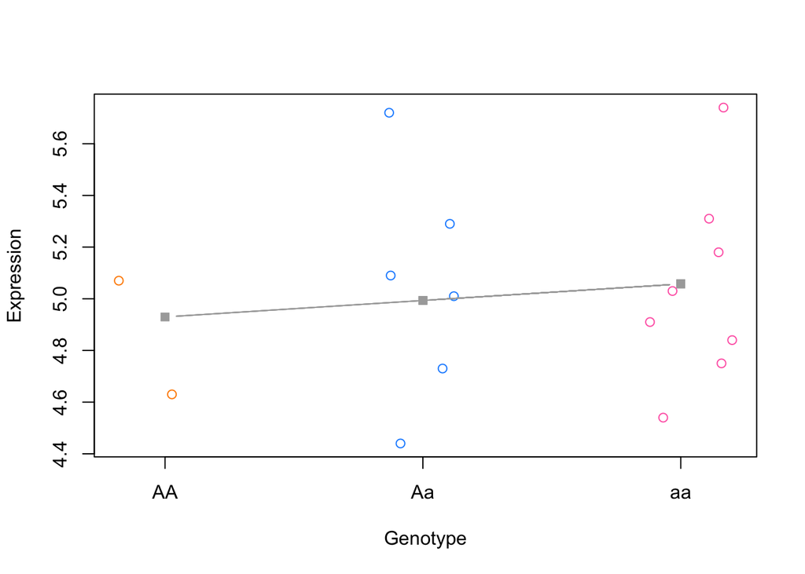

```r
plot(e1 ~ jitter(s1),
     col=(s1+1), xaxt="n", xlab="Genotype", ylab="Expression")
axis(1, at=c(0:2), labels=c("AA","Aa","aa"))
lines(lm1$fitted ~ s1, type="b", pch=15, col="darkgrey")
```

Then we can set up to do every single ones

parameter setup

```r
pvOutputThreshold = 1e-2 # p-val cutoff
errorCovariance = numeric()
useModel = modelLINEAR
```

file setup

```r
snps = SlicedData$new() # create slice data object
snps$fileDelimiter = "\t" # tell delimiter
snps$fileOmitCharacters = "NA" # what is missing value
snps$fileSkipRows = 1 # one row
snps$fileSkipColumns = 1 # one column
snps$fileSliceSize = 2000 # read file in pieces by 2000 rows
snps$LoadFile( SNP_file_name )
```

```
## Rows read: 15 done.
```

```r
gene = SlicedData$new() # create slice data object
gene$fileDelimiter = "\t" # tell delimiter
gene$fileOmitCharacters = "NA" # what is missing value
gene$fileSkipRows = 1 # one row
gene$fileSkipColumns = 1 # one column
gene$fileSliceSize = 2000 # read file in pieces by 2000 rows
gene$LoadFile(expression_file_name)
```

```
## Rows read: 10 done.
```

```r
cvrt = SlicedData$new() # we are leaving this empty for this
```

running eQTL

```r
me = Matrix_eQTL_engine(
  snps=snps,
  gene=gene,
  cvrt=cvrt,
  output_file_name = NULL,
  pvOutputThreshold = pvOutputThreshold,
  useModel = useModel,
  errorCovariance = errorCovariance,
  verbose = TRUE,
  pvalue.hist = TRUE,
  min.pv.by.genesnp = FALSE,
  noFDRsaveMemory = FALSE);
```

```
## Processing covariates
```

```
## Task finished in 0.001 seconds
```

```
## Processing gene expression data (imputation, residualization)
```

```
## Task finished in 0.002 seconds
```

```
## Creating output file(s)
```

```
## Task finished in 0.01 seconds
```

```
## Performing eQTL analysis
```

```
## 100.00% done, 1 eQTLs
```

```
## Task finished in 0.009 seconds
```

plot eQTL

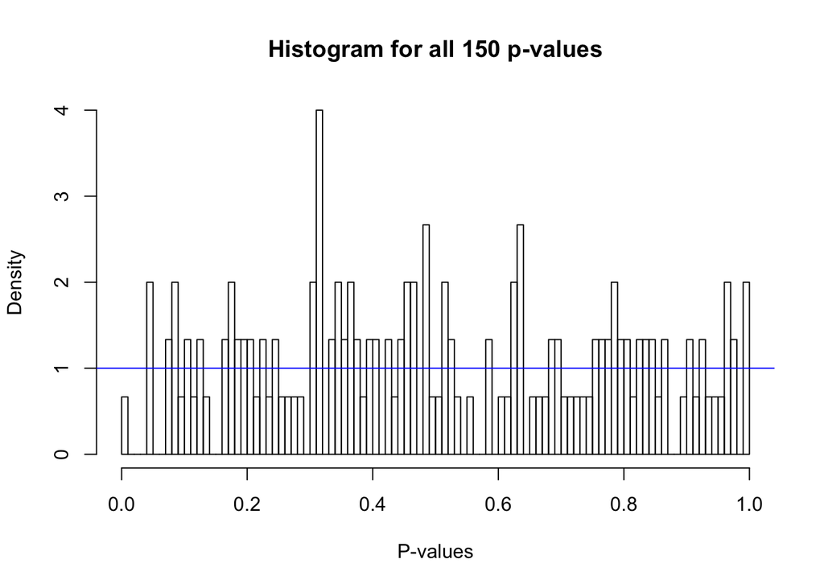

```r
plot(me)
```

```r
me$all$neqtls
```

```
## [1] 1
```

```r
me$all$eqtls
```

```
##     snps    gene statistic     pvalue FDR       beta
## 1 Snp_11 Gene_06 -3.007106 0.00941791   1 -0.2916667
```

## Researcher Degrees of Freedom

1. Have a specific hypothesis
2. Pre-specify analysis plan
3. Use training/testing sets
4. Analyze your data once or report all analyses

## Inference vs. Prediction

Sensitivity, Specificity, Positive Predictive Value, Negative Predictive Value, Accuracy.

One way to solve low PPV is to go at risk population.

1. Prediction with genomics underlies precision medicine

## Statistics for Genomic Data Science Wrap-Up